# Noções Básicas de R - Aula 6

# Arrays

```r
# Construindo um exemplo
a<- array(1:50, dim = c(2,5,5))
a
```

```
## , , 1
##
##      [,1] [,2] [,3] [,4] [,5]
## [1,]    1    3    5    7    9
## [2,]    2    4    6    8   10
##
## , , 2
##
##      [,1] [,2] [,3] [,4] [,5]
## [1,]   11   13   15   17   19
## [2,]   12   14   16   18   20
##
## , , 3
##
##      [,1] [,2] [,3] [,4] [,5]
## [1,]   21   23   25   27   29
## [2,]   22   24   26   28   30
##
## , , 4
##
##      [,1] [,2] [,3] [,4] [,5]
## [1,]   31   33   35   37   39
## [2,]   32   34   36   38   40
##
## , , 5
##
##      [,1] [,2] [,3] [,4] [,5]
## [1,]   41   43   45   47   49
## [2,]   42   44   46   48   50
```

```r
r[,-5] # Não exibe a quinta coluna, ou seja, a variável deltap
```

```
##             h   p1      IMC    pmax
## Augusto  1.70   NA       NA 72.2500
## Bernard  1.74 63.8 21.07280 75.6900
## Carlos   1.63 79.5 29.92209 66.4225
## Cleuler  1.77 81.6 26.04616 78.3225
## Edson    1.83   NA       NA 83.7225
## Helber   1.75 81.3 26.54694 76.5625
## Larissa  1.61 49.0 18.90359 64.8025
## Matheus  1.85 82.7 24.16362 85.5625
## Michelly 1.60 57.6 22.50000 64.0000
## Nayana   1.59 56.3 22.26969 63.2025
## Paula    1.55 72.4 30.13528 60.0625
## Rafael   1.70 62.1 21.48789 72.2500
## Tatiane  1.63 52.6 19.79751 66.4225
## Thiago   1.70 82.1 28.40830 72.2500
## Wesley   1.75 81.9 26.74286 76.5625
```

```r
#rm(rs)
rs<-array(dim = c(15,5,10))
rs
```

```
## , , 1
##
##       [,1] [,2] [,3] [,4] [,5]
##  [1,]   NA   NA   NA   NA   NA
##  [2,]   NA   NA   NA   NA   NA
##  [3,]   NA   NA   NA   NA   NA
##  [4,]   NA   NA   NA   NA   NA
##  [5,]   NA   NA   NA   NA   NA
##  [6,]   NA   NA   NA   NA   NA
##  [7,]   NA   NA   NA   NA   NA
##  [8,]   NA   NA   NA   NA   NA
##  [9,]   NA   NA   NA   NA   NA
## [10,]   NA   NA   NA   NA   NA
## [11,]   NA   NA   NA   NA   NA
## [12,]   NA   NA   NA   NA   NA
```

[output cut: 174 more lines]

```r
rs[,,1]<-r # Transforma um array tipo logic num numeric.
rs[,-5,]
```

```
## , , 1
##
##       [,1] [,2]     [,3]    [,4]
##  [1,] 1.70   NA       NA 72.2500
##  [2,] 1.74 63.8 21.07280 75.6900
##  [3,] 1.63 79.5 29.92209 66.4225
##  [4,] 1.77 81.6 26.04616 78.3225
##  [5,] 1.83   NA       NA 83.7225
##  [6,] 1.75 81.3 26.54694 76.5625
##  [7,] 1.61 49.0 18.90359 64.8025
##  [8,] 1.85 82.7 24.16362 85.5625
##  [9,] 1.60 57.6 22.50000 64.0000
## [10,] 1.59 56.3 22.26969 63.2025
## [11,] 1.55 72.4 30.13528 60.0625
## [12,] 1.70 62.1 21.48789 72.2500
```

[output cut: 174 more lines]

```r
nomes
```

```
##  [1] "Augusto"  "Bernard"  "Carlos"   "Cleuler"  "Edson"    "Helber"
##  [7] "Larissa"  "Matheus"  "Michelly" "Nayana"   "Paula"    "Rafael"
## [13] "Tatiane"  "Thiago"   "Wesley"
```

```r
rownames(rs[,,1:10])<-nomes
#View(rs)
colnames(rs[,,1:10])<-c("altura", "peso","IMC","peso_max","deltap")
#View(rs)
rs[,,1] # As funções rownames e colnames não funcionam como esperado em um array; nem é preciso imprimir todo o <obj> rs para constatar isso
```

```
##       [,1] [,2]     [,3]    [,4]     [,5]
##  [1,] 1.70   NA       NA 72.2500       NA
##  [2,] 1.74 63.8 21.07280 75.6900 -11.8900
##  [3,] 1.63 79.5 29.92209 66.4225  13.0775
##  [4,] 1.77 81.6 26.04616 78.3225   3.2775
##  [5,] 1.83   NA       NA 83.7225       NA
##  [6,] 1.75 81.3 26.54694 76.5625   4.7375
##  [7,] 1.61 49.0 18.90359 64.8025 -15.8025
##  [8,] 1.85 82.7 24.16362 85.5625  -2.8625
##  [9,] 1.60 57.6 22.50000 64.0000  -6.4000
## [10,] 1.59 56.3 22.26969 63.2025  -6.9025
## [11,] 1.55 72.4 30.13528 60.0625  12.3375
## [12,] 1.70 62.1 21.48789 72.2500 -10.1500
## [13,] 1.63 52.6 19.79751 66.4225 -13.8225
## [14,] 1.70 82.1 28.40830 72.2500   9.8500
## [15,] 1.75 81.9 26.74286 76.5625   5.3375
```

```r
#rs<-array(r,dim = c(15,5,10))
rs # o o bjeto array não herda os nomes de colunas e linhas da matriz r.
```

```
## , , 1
##
##       [,1] [,2]     [,3]    [,4]     [,5]
##  [1,] 1.70   NA       NA 72.2500       NA
##  [2,] 1.74 63.8 21.07280 75.6900 -11.8900
##  [3,] 1.63 79.5 29.92209 66.4225  13.0775
##  [4,] 1.77 81.6 26.04616 78.3225   3.2775
##  [5,] 1.83   NA       NA 83.7225       NA
##  [6,] 1.75 81.3 26.54694 76.5625   4.7375
##  [7,] 1.61 49.0 18.90359 64.8025 -15.8025
##  [8,] 1.85 82.7 24.16362 85.5625  -2.8625
##  [9,] 1.60 57.6 22.50000 64.0000  -6.4000
## [10,] 1.59 56.3 22.26969 63.2025  -6.9025
## [11,] 1.55 72.4 30.13528 60.0625  12.3375
## [12,] 1.70 62.1 21.48789 72.2500 -10.1500
```

[output cut: 174 more lines]

```r
#names(rs)[,,1:10]<-c(nomes,c("altura", "peso","IMC","peso_max","deltap"))
#names(rs)[-(1:13),,1:10]<-c("altura", "peso","IMC","peso_max","deltap")
#names(rs)<-c(nomes,c("altura", "peso","IMC","peso_max","deltap"), as.character.Date(dez_semanas)) # Não funcionou a contento

# Talvez dimnames(x) <- value possa funcionar; é preciso testar
dim(rs)
```

```
## [1] 15  5 10
```

```r
as.character.Date(dez_semanas)
```

```
##  [1] "2018-04-04" "2018-04-11" "2018-04-18" "2018-04-25" "2018-05-02"
##  [6] "2018-05-09" "2018-05-16" "2018-05-23" "2018-05-30" "2018-06-06"
```

```r
#dimnames(rs) <- c(nomes,c("altura", "peso","IMC","peso_max","deltap"), as.character.Date(dez_semanas))
# gerou o seguinte erro: "Error in dimnames(rs) <- c(nomes, c("altura", "peso", "IMC", "peso_max",  : 'dimnames' must be a list"
# Ou seja, melhor partir para o uso de data.frame e de list
```

# List

Generalização dos vetores no sentido de que uma lista é uma coleção de objetos de tipos os mais variados.  
São vetores formados por dataframes, “matrizes que permitem que suas colunas tenham diferentes tipos de variáveis etc.

```r
dados<-c(rep(1:4, 2, each = 2))
A = list(x = 1:4, y = matrix(1:4,2,2), w = dados, v = list(B=4,C=5))

A
```

```
## $x
## [1] 1 2 3 4
##
## $y
##      [,1] [,2]
## [1,]    1    3
## [2,]    2    4
##
## $w
##  [1] 1 1 2 2 3 3 4 4 1 1 2 2 3 3 4 4
##
## $v
## $v$B
## [1] 4
##
## $v$C
## [1] 5
```

```r
A[[1]]
```

```
## [1] 1 2 3 4
```

```r
A[[4]]
```

```
## $B
## [1] 4
##
## $C
## [1] 5
```

```r
A$x
```

```
## [1] 1 2 3 4
```

```r
A$y
```

```
##      [,1] [,2]
## [1,]    1    3
## [2,]    2    4
```

```r
A$w
```

```
##  [1] 1 1 2 2 3 3 4 4 1 1 2 2 3 3 4 4
```

```r
A$v
```

```
## $B
## [1] 4
##
## $C
## [1] 5
```

```r
B = list(s = 1:5, r = 2)

Q = c(A,B)

Q
```

```
## $x
## [1] 1 2 3 4
##
## $y
##      [,1] [,2]
## [1,]    1    3
## [2,]    2    4
##
## $w
##  [1] 1 1 2 2 3 3 4 4 1 1 2 2 3 3 4 4
##
## $v
## $v$B
## [1] 4
##
## $v$C
## [1] 5
##
##
## $s
## [1] 1 2 3 4 5
##
## $r
## [1] 2
```

# data.frame

Generalização dos vetores no sentido de que uma data.frame é uma coleção de objetos de tipos os mais variados, mas todos do mesmo tamanho.  
São vetores formados por dataframes, matrizes que permitem que suas colunas tenham diferentes tipos de variáveis etc.  
Usados para guardar tabelas de dados de um problema qualquer.  
Suas colunas tem nomes e podem conter dados de tipos diferentes, diferindo de uma matriz.  
Cada registro da BD corresponde a uma linha da data.frame e cada coluna a uma variável variável, campo ou propriedade das observações coletadas.  
Podem ser criadas pela função data.table()

```r
data(iris)

iris
```

```
##     Sepal.Length Sepal.Width Petal.Length Petal.Width    Species
## 1            5.1         3.5          1.4         0.2     setosa
## 2            4.9         3.0          1.4         0.2     setosa
## 3            4.7         3.2          1.3         0.2     setosa
## 4            4.6         3.1          1.5         0.2     setosa
## 5            5.0         3.6          1.4         0.2     setosa
## 6            5.4         3.9          1.7         0.4     setosa
## 7            4.6         3.4          1.4         0.3     setosa
## 8            5.0         3.4          1.5         0.2     setosa
## 9            4.4         2.9          1.4         0.2     setosa
## 10           4.9         3.1          1.5         0.1     setosa
## 11           5.4         3.7          1.5         0.2     setosa
## 12           4.8         3.4          1.6         0.2     setosa
## 13           4.8         3.0          1.4         0.1     setosa
## 14           4.3         3.0          1.1         0.1     setosa
```

[output cut: 136 more lines]

```r
iris$Sepal.Length
```

```
##   [1] 5.1 4.9 4.7 4.6 5.0 5.4 4.6 5.0 4.4 4.9 5.4 4.8 4.8 4.3 5.8 5.7 5.4
##  [18] 5.1 5.7 5.1 5.4 5.1 4.6 5.1 4.8 5.0 5.0 5.2 5.2 4.7 4.8 5.4 5.2 5.5
##  [35] 4.9 5.0 5.5 4.9 4.4 5.1 5.0 4.5 4.4 5.0 5.1 4.8 5.1 4.6 5.3 5.0 7.0
##  [52] 6.4 6.9 5.5 6.5 5.7 6.3 4.9 6.6 5.2 5.0 5.9 6.0 6.1 5.6 6.7 5.6 5.8
##  [69] 6.2 5.6 5.9 6.1 6.3 6.1 6.4 6.6 6.8 6.7 6.0 5.7 5.5 5.5 5.8 6.0 5.4
##  [86] 6.0 6.7 6.3 5.6 5.5 5.5 6.1 5.8 5.0 5.6 5.7 5.7 6.2 5.1 5.7 6.3 5.8
## [103] 7.1 6.3 6.5 7.6 4.9 7.3 6.7 7.2 6.5 6.4 6.8 5.7 5.8 6.4 6.5 7.7 7.7
## [120] 6.0 6.9 5.6 7.7 6.3 6.7 7.2 6.2 6.1 6.4 7.2 7.4 7.9 6.4 6.3 6.1 7.7
## [137] 6.3 6.4 6.0 6.9 6.7 6.9 5.8 6.8 6.7 6.7 6.3 6.5 6.2 5.9
```

```r
iris$Renato = TRUE

iris
```

```
##     Sepal.Length Sepal.Width Petal.Length Petal.Width    Species Renato
## 1            5.1         3.5          1.4         0.2     setosa   TRUE
## 2            4.9         3.0          1.4         0.2     setosa   TRUE
## 3            4.7         3.2          1.3         0.2     setosa   TRUE
## 4            4.6         3.1          1.5         0.2     setosa   TRUE
## 5            5.0         3.6          1.4         0.2     setosa   TRUE
## 6            5.4         3.9          1.7         0.4     setosa   TRUE
## 7            4.6         3.4          1.4         0.3     setosa   TRUE
## 8            5.0         3.4          1.5         0.2     setosa   TRUE
## 9            4.4         2.9          1.4         0.2     setosa   TRUE
## 10           4.9         3.1          1.5         0.1     setosa   TRUE
## 11           5.4         3.7          1.5         0.2     setosa   TRUE
## 12           4.8         3.4          1.6         0.2     setosa   TRUE
## 13           4.8         3.0          1.4         0.1     setosa   TRUE
## 14           4.3         3.0          1.1         0.1     setosa   TRUE
```

[output cut: 136 more lines]

```r
rs<-data.table(nomes,h,p1,IMC,pmax,deltap)
rs[,-6]
```

```
##        nomes    h   p1      IMC    pmax
##  1:  Augusto 1.70   NA       NA 72.2500
##  2:  Bernard 1.74 63.8 21.07280 75.6900
##  3:   Carlos 1.63 79.5 29.92209 66.4225
##  4:  Cleuler 1.77 81.6 26.04616 78.3225
##  5:    Edson 1.83   NA       NA 83.7225
##  6:   Helber 1.75 81.3 26.54694 76.5625
##  7:  Larissa 1.61 49.0 18.90359 64.8025
##  8:  Matheus 1.85 82.7 24.16362 85.5625
##  9: Michelly 1.60 57.6 22.50000 64.0000
## 10:   Nayana 1.59 56.3 22.26969 63.2025
## 11:    Paula 1.55 72.4 30.13528 60.0625
## 12:   Rafael 1.70 62.1 21.48789 72.2500
## 13:  Tatiane 1.63 52.6 19.79751 66.4225
## 14:   Thiago 1.70 82.1 28.40830 72.2500
## 15:   Wesley 1.75 81.9 26.74286 76.5625
```

```r
rs[,-1]
```

```
##        h   p1      IMC    pmax   deltap
##  1: 1.70   NA       NA 72.2500       NA
##  2: 1.74 63.8 21.07280 75.6900 -11.8900
##  3: 1.63 79.5 29.92209 66.4225  13.0775
##  4: 1.77 81.6 26.04616 78.3225   3.2775
##  5: 1.83   NA       NA 83.7225       NA
##  6: 1.75 81.3 26.54694 76.5625   4.7375
##  7: 1.61 49.0 18.90359 64.8025 -15.8025
##  8: 1.85 82.7 24.16362 85.5625  -2.8625
##  9: 1.60 57.6 22.50000 64.0000  -6.4000
## 10: 1.59 56.3 22.26969 63.2025  -6.9025
## 11: 1.55 72.4 30.13528 60.0625  12.3375
## 12: 1.70 62.1 21.48789 72.2500 -10.1500
## 13: 1.63 52.6 19.79751 66.4225 -13.8225
## 14: 1.70 82.1 28.40830 72.2500   9.8500
## 15: 1.75 81.9 26.74286 76.5625   5.3375
```

```r
nrow(rs)
```

```
## [1] 15
```

```r
ncol(rs)
```

```
## [1] 6
```

```r
s
```

```
##  [1] m m m m m m f m f f f m f m m
## Levels: f m
```

```r
rs$sexo<-s
rs
```

```
##        nomes    h   p1      IMC    pmax   deltap sexo
##  1:  Augusto 1.70   NA       NA 72.2500       NA    m
##  2:  Bernard 1.74 63.8 21.07280 75.6900 -11.8900    m
##  3:   Carlos 1.63 79.5 29.92209 66.4225  13.0775    m
##  4:  Cleuler 1.77 81.6 26.04616 78.3225   3.2775    m
##  5:    Edson 1.83   NA       NA 83.7225       NA    m
##  6:   Helber 1.75 81.3 26.54694 76.5625   4.7375    m
##  7:  Larissa 1.61 49.0 18.90359 64.8025 -15.8025    f
##  8:  Matheus 1.85 82.7 24.16362 85.5625  -2.8625    m
##  9: Michelly 1.60 57.6 22.50000 64.0000  -6.4000    f
## 10:   Nayana 1.59 56.3 22.26969 63.2025  -6.9025    f
## 11:    Paula 1.55 72.4 30.13528 60.0625  12.3375    f
## 12:   Rafael 1.70 62.1 21.48789 72.2500 -10.1500    m
## 13:  Tatiane 1.63 52.6 19.79751 66.4225 -13.8225    f
## 14:   Thiago 1.70 82.1 28.40830 72.2500   9.8500    m
## 15:   Wesley 1.75 81.9 26.74286 76.5625   5.3375    m
```

```r
rs$f_altura<-hcat
rs
```

```
##        nomes    h   p1      IMC    pmax   deltap sexo f_altura
##  1:  Augusto 1.70   NA       NA 72.2500       NA    m    Médio
##  2:  Bernard 1.74 63.8 21.07280 75.6900 -11.8900    m     Alto
##  3:   Carlos 1.63 79.5 29.92209 66.4225  13.0775    m    Médio
##  4:  Cleuler 1.77 81.6 26.04616 78.3225   3.2775    m     Alto
##  5:    Edson 1.83   NA       NA 83.7225       NA    m     Alto
##  6:   Helber 1.75 81.3 26.54694 76.5625   4.7375    m     Alto
##  7:  Larissa 1.61 49.0 18.90359 64.8025 -15.8025    f    Médio
##  8:  Matheus 1.85 82.7 24.16362 85.5625  -2.8625    m     Alto
##  9: Michelly 1.60 57.6 22.50000 64.0000  -6.4000    f    Baixo
## 10:   Nayana 1.59 56.3 22.26969 63.2025  -6.9025    f    Baixo
## 11:    Paula 1.55 72.4 30.13528 60.0625  12.3375    f    Baixo
## 12:   Rafael 1.70 62.1 21.48789 72.2500 -10.1500    m    Médio
## 13:  Tatiane 1.63 52.6 19.79751 66.4225 -13.8225    f    Médio
## 14:   Thiago 1.70 82.1 28.40830 72.2500   9.8500    m    Médio
## 15:   Wesley 1.75 81.9 26.74286 76.5625   5.3375    m     Alto
```

```r
# A ideia é criar um list de 10 posições para receber as amostras de 10 semanas

# no intervalor é possível criar um data.frame similar e editar para carregar os dados da aula passada e desta aula
```

```r
# Exibindo essa diferença graficamente
boxplot(rs$h~rs$sexo, ylab = "altura", xlab="sexo") # homens são, em média, mais alto que as mulheres
```

[output not shown]

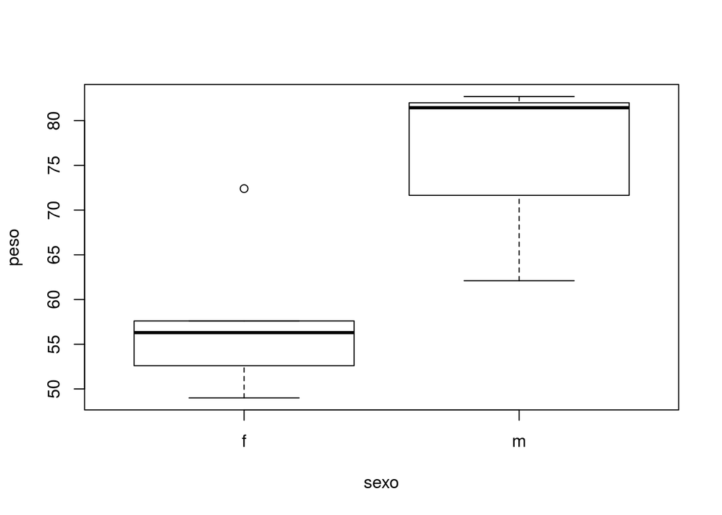

```r
boxplot(rs$p1~rs$sexo, ylab = "peso", xlab="sexo") # homens são, em média, mais pesados que as mulheres
```

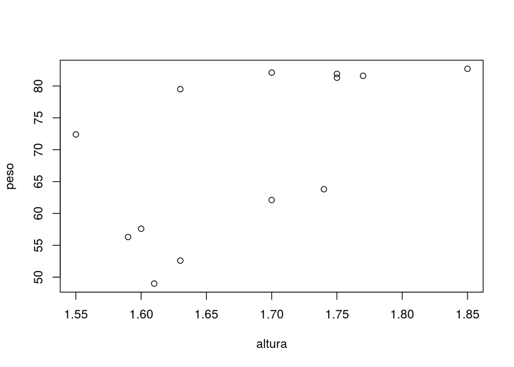

```r
plot(rs$p1~rs$h, ylab = "peso", xlab="altura")
```

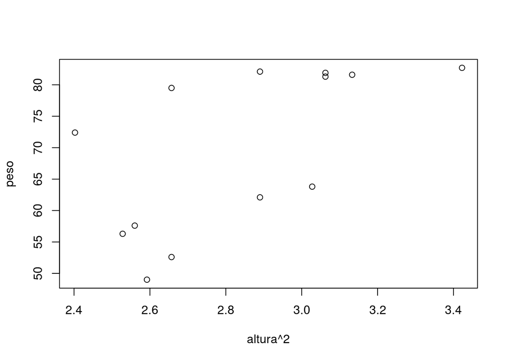

```r
rs$h2<-rs$h^2
plot(rs$p1~rs$h2, ylab = "peso", xlab="altura^2")
```

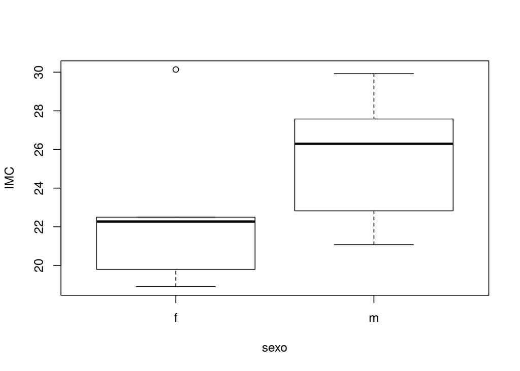

```r
# Esses gráficos corroboram uma Hipótese de estratificação f & m para analisar o IMC?????
# Duvidar é preciso. Viver não é preciso.
# Transformar sua dúvida numa hipótese testável.
# E testar adequadamente a Hipótese **contra** as observações colhidas no campo.

boxplot(rs$IMC~rs$sexo, ylab = "IMC", xlab="sexo")
```

# Exercícios - Para Resolução em Sala com o uso de matrizes

Refletir e responder às seguintes questões *pragmáticas* com o uso de matrizes:  
1) Qual a altura média da sua turma de R na aula do dia 11 abr. 2018?  
2) Qual o peso médio da sua turma de R decorrente das observações registradas nas aulas desde o dia 11 abr. 2018?  
3) Qual o peso médio de cada aluno da sua turma de R decorrente das observações registradas nas aulas desde o dia 11 abr. 2018? 4) Qual o número médio de caracteres dos prenomes dos alunos da turma de R que mediram seus pesos desde o dia 11 abr. 2018?  
5) Qual o desvio padrão dessas médias encontradas?  
6) Quem está abaixo e acima da média de peso mais ou menos 1 Desvio Padrão? Qual o resultado para 0.5 e 1.5 DP? 7) Calcular o IMC de cada observação desde o dia 11 abr. 2018. Encontre sua média e dp? 8) Quem está abaixo e acima da média do IMC mais ou menos 1 Desvio Padrão? Qual o resultado para 0.5 e 1.5 DP?

```r
#Criando uma função para encontrar a média e o DP de um <vctr> ou de uma <mtrx>.
#Esses valores retornarão após o último elemento do <vctr>
#Se for uma <mtrx> retornarão por linha (row=TRUE) após sua última coluna.
#ou por coluna (col=TRUE) após a última linha da <mtrx>.
media_dp<-function(m,dp=TRUE,row=TRUE,col=TRUE) {
  if(is.vector(m)) {
    n<-length(m)
    m[n+1]<-mean(m,na.rm = TRUE)
    if(dp==TRUE) {
      m[n+2]<-sd(m[1:n],na.rm = TRUE)
    }#fim do if(dp==TRUE)
    return(m)
  #fim do if is.vector(m)
  } else {
    l<-nrow(m)
    c<-ncol(m)

  if(is.matrix(m)) {
    if(row==TRUE) {
      # A linha seguinte é para evitar o erro: Error in `[<-`(`*tmp*`, i, c + 1, value = 79.8) : subscript out of bounds
      m<-cbind(m,matrix(data = NA, nrow = l, ncol = 2, byrow =   FALSE,dimnames = NULL))
      for (i in 1:l) {
        m[i,c+1]<-mean(m[i,],na.rm = TRUE)
        if(dp==TRUE){m[i,c+2]<-sd(m[i,1:c],na.rm = TRUE)}#fim do if
      }#fim do for para calcular média e DP de cada linha
    }#fim do if (row==TRUE)
    if(col==TRUE) {
      # A linha seguinte é para evitar o erro: Error in `[<-`(`*tmp*`, i, c + 1, value = 79.8) : subscript out of bounds
      m<-rbind(m,matrix(data = NA, nrow = 2, ncol = c, byrow =   FALSE,dimnames = NULL))
      for (j in 1:c) {
        m[l+1,j]<-mean(m[,j],na.rm = TRUE)
        if(dp==TRUE){m[l+2,j]<-sd(m[1:l,j],na.rm = TRUE)}#fim do if
      }#fim do for para calcular média e DP de cada coluna
    }#fim do if (col==TRUE)
    return(m)
  }#fim do if is.matrix(m)
 }#fim do else do if is.vector(m)
}#fim da function media_dp()
```

# Linguagem R: importância de explorar a sua funcionalidade e a sua orientação a objeto

```r
getwd()
```

```
## [1] "/home/modanez/repositorios/aulas/06-aula"
```

```r
load("dados.RData")
names(dados)<-tolower(names(dados)) # recodifica os nomes das variáveis para minúsculas

#Inspecionando os dados da nossa BD
#Calculando a altura média da turma e seu desvio padrão
dados$altura
```

```
##  [1] 1.70 1.74 1.63 1.77 1.83 1.75 1.61 1.85 1.60 1.59 1.55 1.70 1.63 1.70
## [15] 1.75
```

```r
dados$altura[dados$sexo=="m"] # são 10 pessoas do sexo masculino
```

```
##  [1] 1.70 1.74 1.63 1.77 1.83 1.75 1.85 1.70 1.70 1.75
```

```r
dados$altura[dados$sexo=="f"] # são  5 pessoas do sexo feminino
```

```
## [1] 1.61 1.60 1.59 1.55 1.63
```

```r
media_dp(m = dados$altura,dp = TRUE)
```

```
##  [1] 1.70000000 1.74000000 1.63000000 1.77000000 1.83000000 1.75000000
##  [7] 1.61000000 1.85000000 1.60000000 1.59000000 1.55000000 1.70000000
## [13] 1.63000000 1.70000000 1.75000000 1.69333333 0.08973506
```

```r
media_dp(m = dados$altura[dados$sexo=="m"],dp = TRUE)
```

```
##  [1] 1.70000000 1.74000000 1.63000000 1.77000000 1.83000000 1.75000000
##  [7] 1.85000000 1.70000000 1.70000000 1.75000000 1.74200000 0.06511528
```

```r
media_dp(m = dados$altura[dados$sexo=="f"],dp = TRUE)
```

```
## [1] 1.61000000 1.60000000 1.59000000 1.55000000 1.63000000 1.59600000
## [7] 0.02966479
```

```r
media_dp(m = dados$x2018.04.11,dp = TRUE)
```

```
##  [1]       NA 63.80000 79.50000 81.60000       NA 81.30000 49.00000
##  [8] 82.70000 57.60000 56.30000 72.40000 62.10000 52.60000 82.10000
## [15] 81.90000 69.45385 12.87683
```

```r
media_dp(m = dados$x2018.04.18,dp = TRUE)
```

```
##  [1]       NA       NA 79.50000 81.00000       NA       NA 49.10000
##  [8]       NA       NA 55.30000 72.80000 62.20000 52.50000 81.70000
## [15] 83.20000 68.58889 13.83966
```

```r
media_dp(m = dados$x2018.04.25,dp = TRUE)
```

```
##  [1]  79.80000  63.70000  80.10000  82.10000 116.40000  81.70000  48.40000
##  [8]  82.20000        NA  56.00000  72.30000  61.00000  51.70000  82.40000
## [15]        NA  73.67692  17.99209
```

```r
media_dp(m = dados$x2018.05.02,dp = TRUE)
```

```
##  [1]  NA  NA  NA  NA  NA  NA  NA  NA  NA  NA  NA  NA  NA  NA  NA NaN  NA
```

```r
#Observa-se uma forte oscilação na média de peso da turma em cada observação, em razão das faltas sistemáticas de alguns alunos
# Como evitar que esse fato interfira na tentativa de observar se uma simples recomendação de adoção de uma dieta do meio, do terço ou da sesma é ou não capaz de alterar a média do peso da turma ao longo de um curso de R com 10 semanas de duração?

# verificando o peso médio e o DP para cada aluno desde a 2ª aula
media_dp(m = as.matrix(dados[,4:6]),dp = TRUE, row = TRUE, col = FALSE) # é necessário transformar dados <data.frame> em <mtrx> porque senão o teste is.matrix resultará em FALSE na função chamada
```

```
##       x2018.04.11 x2018.04.18 x2018.04.25
##  [1,]          NA          NA        79.8  79.80000         NA
##  [2,]        63.8          NA        63.7  63.75000 0.07071068
##  [3,]        79.5        79.5        80.1  79.70000 0.34641016
##  [4,]        81.6        81.0        82.1  81.56667 0.55075705
##  [5,]          NA          NA       116.4 116.40000         NA
##  [6,]        81.3          NA        81.7  81.50000 0.28284271
##  [7,]        49.0        49.1        48.4  48.83333 0.37859389
##  [8,]        82.7          NA        82.2  82.45000 0.35355339
##  [9,]        57.6          NA          NA  57.60000         NA
## [10,]        56.3        55.3        56.0  55.86667 0.51316014
## [11,]        72.4        72.8        72.3  72.50000 0.26457513
## [12,]        62.1        62.2        61.0  61.76667 0.66583281
## [13,]        52.6        52.5        51.7  52.26667 0.49328829
## [14,]        82.1        81.7        82.4  82.06667 0.35118846
## [15,]        81.9        83.2          NA  82.55000 0.91923882
```

```r
teste.peso.obs<-media_dp(m = as.matrix(dados[,4:6]),dp = TRUE, row = TRUE, col = FALSE)

teste.peso.aula<-media_dp(m = as.matrix(dados[,4:6]),dp = TRUE, row = FALSE, col = TRUE)
teste.peso.aula
```

```
##       x2018.04.11 x2018.04.18 x2018.04.25
##  [1,]          NA          NA    79.80000
##  [2,]    63.80000          NA    63.70000
##  [3,]    79.50000    79.50000    80.10000
##  [4,]    81.60000    81.00000    82.10000
##  [5,]          NA          NA   116.40000
##  [6,]    81.30000          NA    81.70000
##  [7,]    49.00000    49.10000    48.40000
##  [8,]    82.70000          NA    82.20000
##  [9,]    57.60000          NA          NA
## [10,]    56.30000    55.30000    56.00000
## [11,]    72.40000    72.80000    72.30000
## [12,]    62.10000    62.20000    61.00000
## [13,]    52.60000    52.50000    51.70000
## [14,]    82.10000    81.70000    82.40000
## [15,]    81.90000    83.20000          NA
## [16,]    69.45385    68.58889    73.67692
## [17,]    12.87683    13.83966    17.99209
```

```r
#Verificando se a média das médias dos pesos por dia de aula é a mesma da média das médias dos pesos por aluno
media_dp(m=as.vector(teste.peso.obs[,4]),dp=TRUE)
```

```
##  [1]  79.80000  63.75000  79.70000  81.56667 116.40000  81.50000  48.83333
##  [8]  82.45000  57.60000  55.86667  72.50000  61.76667  52.26667  82.06667
## [15]  82.55000  73.24111  17.19380
```

```r
media_dp(m=as.vector(teste.peso.aula[16,]),dp=TRUE)
```

```
## [1] 69.453846 68.588889 73.676923 70.573219  2.722457
```

```r
#Resultado: nem a média nem o desvio padrão resutaram os mesmos!!!
#Era esperado que não resultasse o mesmo desvio padrão (NA's)
#Mas é refoge às expectativas que não resulte na mesma média dos pesos
# Ocorre que com nem todos os alunos compareceram a todas as aulas, então o número de observações do peso de cada um deles varia e, assim, varia o denominador para o cálculo da média de cada um dos faltantes. Cada aluno que falta provoca uma oscilação no valor da média do peso em cada dia de aula e uma alteração de seu denominador.
```

```r
#3) Número médio de caracteres dos prenomes dos alunos da turma de R que mediram seus pesos no dia 11 abr. 2018 e seu Desvio Padrão (#5)
mean(length(dados$nome))
```

```
## [1] 15
```

```r
sd(mean(length(dados$nome))) # retorna um NA. Por que?
```

```
## [1] NA
```

```r
dados$nome
```

```
##  [1] Augusto  Bernard  Carlos   Cleuler  Edson    Helber   Larissa
##  [8] Matheus  Michelly Nayana   Paula    Rafael   Tatiane  Thiago
## [15] Wesley
## 15 Levels: Augusto Bernard Carlos Cleuler Edson Helber Larissa ... Wesley
```

```r
tam_nomes<-length(dados$nome) # cuidado porque retorna o comprimento do vetor names = 15L <fctr>!!!
tam_nomes<-nchar(as.vector(dados$nome), keepNA = NA)
tam_nomes
```

```
##  [1] 7 7 6 7 5 6 7 7 8 6 5 6 7 6 6
```

```r
tam_nomes_media<-mean(tam_nomes)
tam_nomes_media
```

```
## [1] 6.4
```

```r
tam_nomes_DP   <-sd(tam_nomes)
tam_nomes_DP
```

```
## [1] 0.8280787
```

```r
#6) Quem está abaixo e acima da média mais ou menos 1 Desvio Padrão?
tam_nomes[tam_nomes<tam_nomes_media-tam_nomes_DP | tam_nomes>tam_nomes_media+tam_nomes_DP]
```

```
## [1] 5 8 5
```

```r
nomes[tam_nomes<tam_nomes_media-tam_nomes_DP | tam_nomes>tam_nomes_media+tam_nomes_DP] # Eis os nomes daqueles com tamanhos de nomes outliers da nossa turma.
```

```
## [1] "Edson"    "Michelly" "Paula"
```

```r
#7 e 8) Cálculo do IMC de cada observação desde o dia 11 abr. 2018.
#O cálculo do IMC é feito dividindo o peso (em quilogramas) pela altura (em metros) elevada ao quadrado.
IMC<-as.matrix(dados[,4:6]/dados$altura^2)
media_dp(m = IMC,dp = TRUE, row = TRUE, col = FALSE)
```

```
##       x2018.04.11 x2018.04.18 x2018.04.25
##  [1,]          NA          NA    27.61246 27.61246         NA
##  [2,]    21.07280          NA    21.03977 21.05628 0.02335536
##  [3,]    29.92209    29.92209    30.14792 29.99737 0.13038133
##  [4,]    26.04616    25.85464    26.20575 26.03552 0.17579784
##  [5,]          NA          NA    34.75768 34.75768         NA
##  [6,]    26.54694          NA    26.67755 26.61224 0.09235680
##  [7,]    18.90359    18.94217    18.67212 18.83929 0.14605682
##  [8,]    24.16362          NA    24.01753 24.09058 0.10330267
##  [9,]    22.50000          NA          NA 22.50000         NA
## [10,]    22.26969    21.87413    22.15102 22.09828 0.20298253
## [11,]    30.13528    30.30177    30.09365 30.17690 0.11012492
## [12,]    21.48789    21.52249    21.10727 21.37255 0.23039198
## [13,]    19.79751    19.75987    19.45877 19.67205 0.18566310
## [14,]    28.40830    28.26990    28.51211 28.39677 0.12151850
## [15,]    26.74286    27.16735          NA 26.95510 0.30015961
```

```r
teste.IMC<-media_dp(m = IMC,dp = TRUE, row = TRUE, col = FALSE)
IMC_m<- mean(teste.IMC[,(ncol(IMC)+1)], na.rm=TRUE) # É uma uma turma de magros!!! Conclusão precipitada?
IMC_m # = 25.17 Kg/m2 (2ª aula) # O IMC médio da turma (4ª aula) = 25.34487 indica que "ela está ligeiramente acima do peso normal" [?] - Cuidado para não "reificar" sua unidade populacional
```

```
## [1] 25.34487
```

```r
IMC_DP<-sd(teste.IMC[,(ncol(IMC)+1)], na.rm=TRUE)
IMC_DP# =  3.61 Kg/m2 (2ª aula); 4.49 Kg/m2 (2ª a 4ª aulas)
```

```
## [1] 4.484967
```

```r
IMC[IMC<18.5 | IMC>=25]
```

```
##  [1]       NA 29.92209 26.04616       NA 26.54694 30.13528 28.40830
##  [8] 26.74286       NA       NA 29.92209 25.85464       NA       NA
## [15]       NA       NA 30.30177 28.26990 27.16735 27.61246 30.14792
## [22] 26.20575 34.75768 26.67755       NA 30.09365 28.51211       NA
```

```r
dados$nome[IMC<18.5 | IMC>=25] # Há um problema lógico nessa expressão? Qual seria?            !!!!!!!!!!!!!!!!!!!!!!!!!!
```

```
##  [1] <NA>    Carlos  Cleuler <NA>    Helber  Paula   Thiago  Wesley
##  [9] <NA>    <NA>    <NA>    <NA>    <NA>    <NA>    <NA>    <NA>
## [17] <NA>    <NA>    <NA>    <NA>    <NA>    <NA>    <NA>    <NA>
## [25] <NA>    <NA>    <NA>    <NA>
## 15 Levels: Augusto Bernard Carlos Cleuler Edson Helber Larissa ... Wesley
```

```r
boxplot(dados$altura~dados$sexo, ylab = "altura", xlab="sexo") # homens são, em média, mais alto que as mulheres
```

[output not shown]

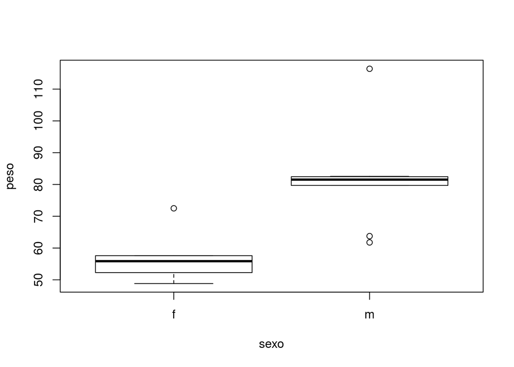

```r
boxplot(teste.peso.obs[,4]~dados$sexo, ylab = "peso", xlab="sexo") # homens são, em média, mais pesados que as mulheres
```

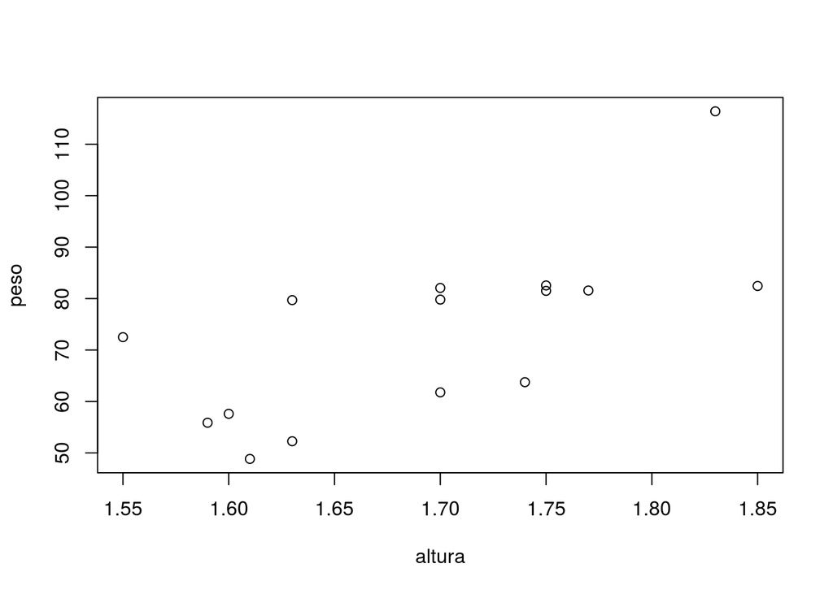

```r
plot(teste.peso.obs[,4]~dados$altura, ylab = "peso", xlab="altura")
```

```r
dados.teste<-cbind(dados,teste.peso.obs[,4:5],teste.IMC[,4:5])

boxplot(dados.teste$altura~dados.teste$sexo, ylab = "altura", xlab="sexo") # homens são, em média, mais alto que as mulheres
```

[output not shown]